# S. pennellii RNAseq simulations

# Remove overlapping genes and plot

Genes with more than one *S.lyc* or more than one *S.pen* annotation overlap are removed.

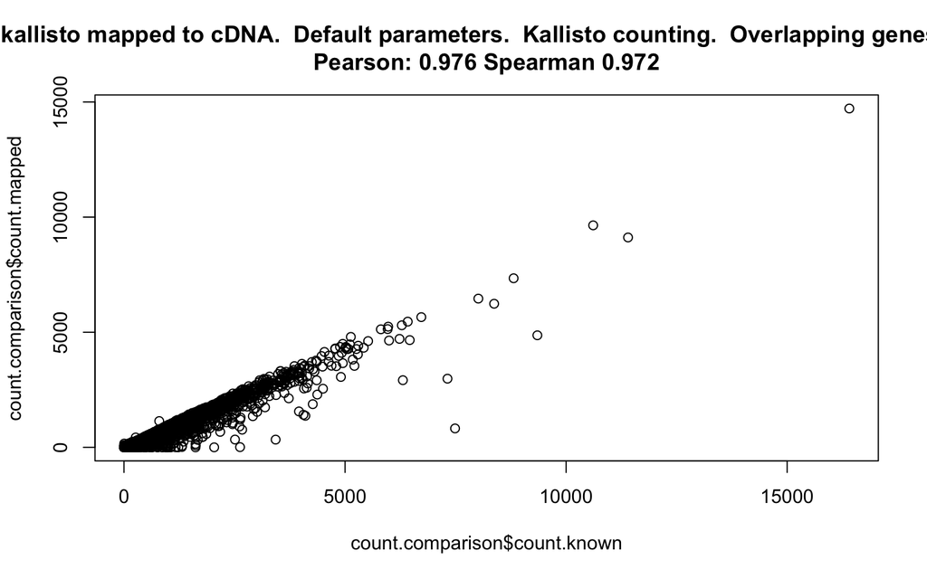

Pretty good!

# Kallisto with 21nt kmers

# build index

only needs to be done once:

```bash
kallisto index -k 21 -i ITAG2.4._cds.pen.orthlogsonly.21.kai ~/Sequences/ref_genomes/tomato/ITAG2.4_Chromo2.5/ITAG2.4_cds.pen.orthologs.only.fasta
```

# run kallisto

```r
RunKallisto(fasta = "spen_sim_2/sample_01_renamed.fastq.gz", index = "ITAG2.4._cds.pen.orthlogsonly.21.kai", dir = "spen_sim_2/kallisto21" )
```

# Load in mapped counts

```r
pen.mapped.counts <- GetMappedCounts(dir = "spen_sim_2/kallisto21", type="kallisto-transcripts")
```

# *S. pennellii*

Compare known to mapped counts

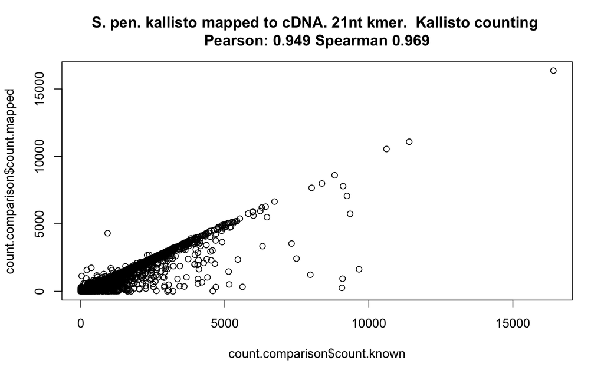

# Remove overlapping genes and plot

Genes with more than one *S.lyc* or more than one *S.pen* annotation overlap are removed.

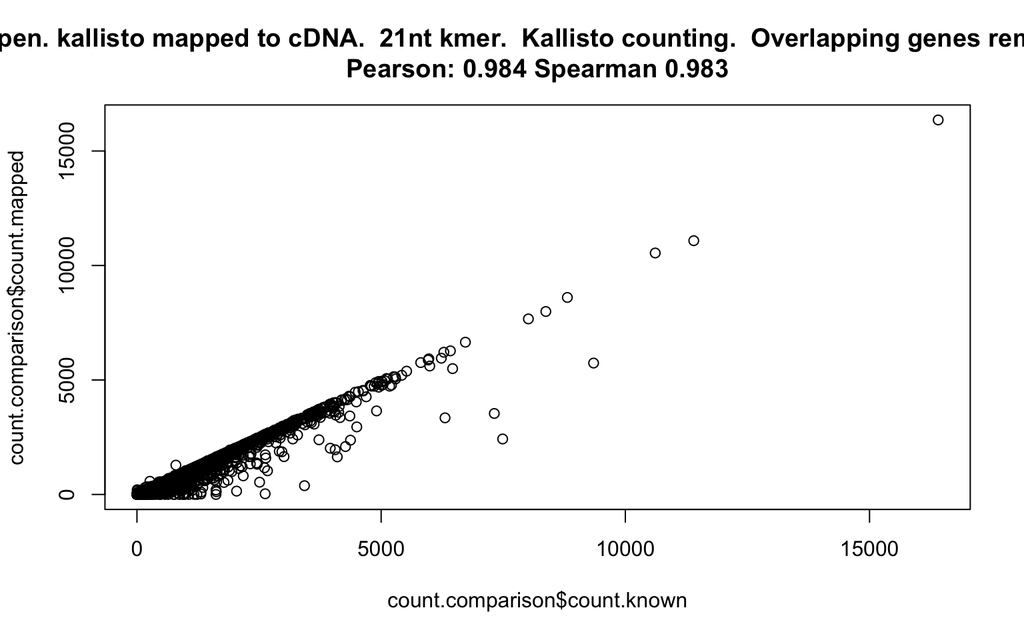

Pretty good!

# Optimize Kallisto kmer

# Idea

Lowering the kallisto kmer improved the correlation between known and mapped counts

What is the best kmer?

In this section I will try a bunch of kmers

# Build kalliso indexes for different kmers.

```r
#only run once...it will be slow!
library(snowfall)
kmers <- c(seq(11,19,2),seq(23,29,2)) #21 and 31 already done
sfInit(cpu=min(kmers,12),parallel = TRUE)
sfClusterApply(kmers, function(k) {
  index.name <- paste("ITAG2.4._cds.pen.orthlogsonly.",k,".kai",sep="")
  system(paste("kallisto index -k", k,
               " -i", index.name,
               "~/Sequences/ref_genomes/tomato/ITAG2.4_Chromo2.5/ITAG2.4_cds.pen.orthologs.only.fasta"))})
sfStop()
```

# Run Kallisto on the different indicies

```r
library(snowfall)
indicies <- dir(pattern="[0-9]\\.kai")
sfInit(cpu=2,parallel = TRUE)
```

```
## R Version:  R version 3.2.3 (2015-12-10)
```

```
## snowfall 1.84-6.1 initialized (using snow 0.4-1): parallel execution on 2 CPUs.
```

```r
sfSource("Rnaseq_sim_helper_functions.R")
```

```
## Source Rnaseq_sim_helper_functions.R loaded.
```

```
## Source Rnaseq_sim_helper_functions.R loaded in cluster.
```

[output not shown]

```r
sfExport("pen.known.counts","lyc.lyc.overlaps","pen.pen.overlaps","pen.gene.length","lyc.gene.length")
results.combined <- sfLapply(indicies,function(i) {
  kmer <- sub("ITAG2\\.4\\._cds\\.pen\\.orthlogsonly\\.([0-9]{2})\\.kai","\\1",i)
  dir.out <- paste("spen_sim_2/kallisto",kmer,sep="")
  results <- list()
  results$kmer <- as.numeric(kmer)
  results$time <- system.time(RunKallisto(fasta = "spen_sim_2/sample_01_renamed.fastq.gz",
              index = i,
              dir = dir.out))
  pen.mapped.counts <- GetMappedCounts(dir = dir.out, type="kallisto-transcripts")
  pen.count.comparison <- CompareCounts(pen.known.counts,pen.mapped.counts,plot = FALSE,correlation = FALSE)
  pen.count.comparison$flag <- "none"
  pen.count.comparison <- within(pen.count.comparison,{
                                 flag[pen.count.comparison$lyc.id %in% lyc.lyc.overlaps] <- "lyc.lyc.overlap"
                                 flag[pen.count.comparison$lyc.id %in% pen.pen.overlaps] <- "pen.pen.overlap"
                                 }
                                 )
  results$corr.all <- with(pen.count.comparison,c(cor(count.known, count.mapped),cor(count.known,count.mapped,method="spearman")))
  results$corr.bad.removed <- with(pen.count.comparison[pen.count.comparison$flag=="none",],
                                   c(cor(count.known, count.mapped),cor(count.known,count.mapped,method="spearman")))
  return(results)
})
sfStop()
```

```
##
## Stopping cluster
```

# kalliso kmer effects

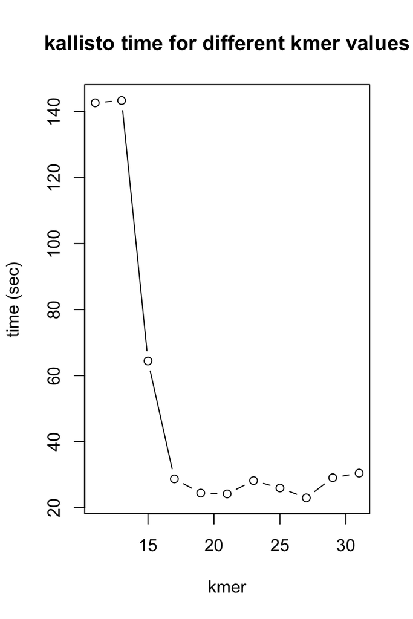

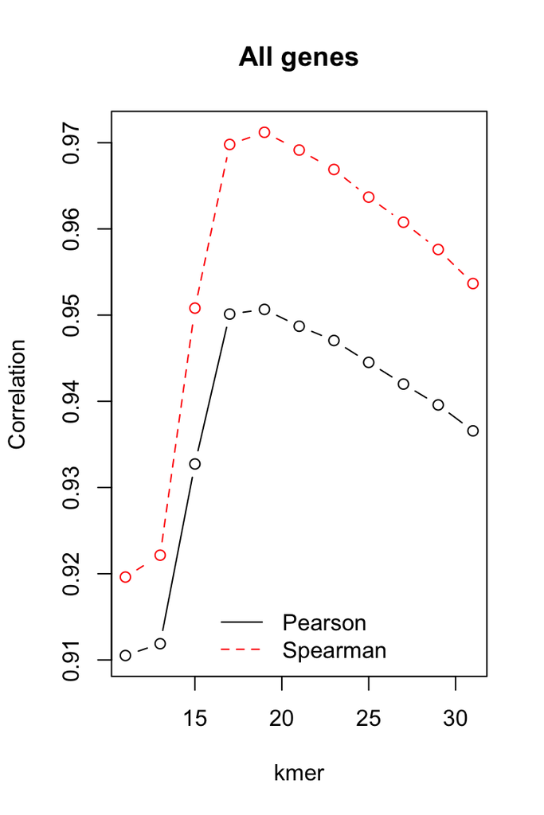

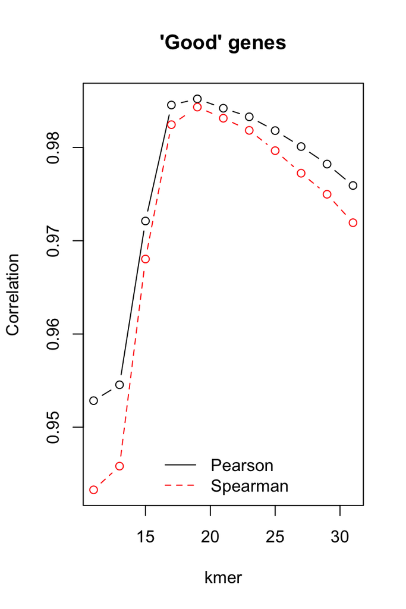

So, kmer=19 is the best

# Mapping to genomic with subread

# Installation

Download subread

untar and unzip it, move binaries to /usr/local/bin (or make symbolic links)

```r
# in R
install.pacakges("Rsubread")
```

# Build Indexes

```r
library(Rsubread)
buildindex("Slyc_Chromo2.5_subread_index","/Users/jmaloof/Sequences/ref_genomes/tomato/ITAG2.4_Chromo2.5/S_lycopersicum_chromosomes.2.50.fa") #note does not do tilde expansion
# 5.5 minutes
```

# Map

```r
system.time(align("Slyc_Chromo2.5_subread_index","spen_sim_2/sample_01_renamed.fastq.gz", nthreads = 2))
```

On Royce, with 2 threads: user system elapsed 310.463 32.216 211.111

# Get Counts

```r
pen.mapped.counts <- GetMappedCounts(dir="spen_sim_2/",type = "featureCounts",bam = "sample_01_renamed.fastq.gz.subread.BAM")
```

[output not shown]

# Compare counts

Compare known to mapped counts

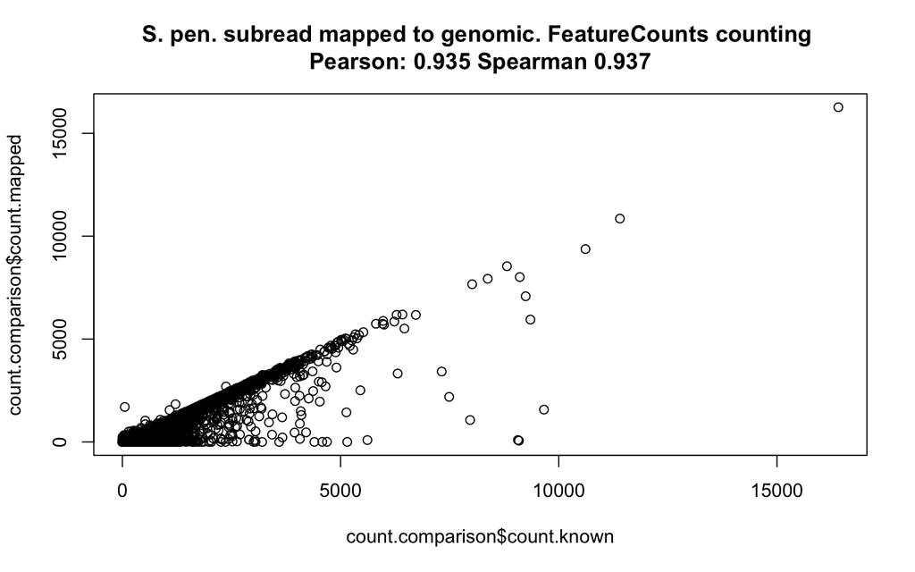

# Remove overlapping genes and compare

Genes with more than one *S.lyc* or more than one *S.pen* annotation overlap are removed.

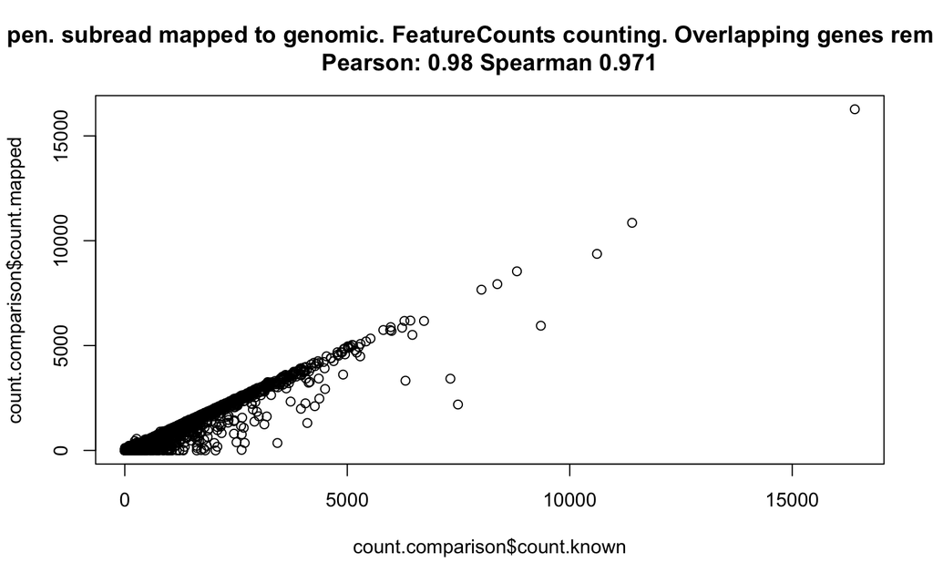